# 房地产开发相关岗位招聘和薪酬水平

## 总述

本次采集有效数据5140条（城市发布量>=100）,主要分析房地产开发相关岗位招聘和薪酬水平，岗位如策划经理或主管、土建工程师、安装工程师、景观工程师、水电/机电工程师、精装修工程师、土建造价、安装造价等。我们将从如下方面分析：

- 01.城市分布：广州占14%，平均月薪14683元；深圳占12%，平均月薪17186元；上海占10%，平均月薪16357元，成都占9%，平均月薪13331元，其余城市均在7%或以下。
- 02.行业分布：房地产占60%，平均月薪15897元；建筑/建材/工程占10%，平均月薪11607元。
- 03.公司规模：1000人以下占79%，平均月薪14672元；1000-5000人占12%，平均月薪15901元。
- 04.公司类型：民企占65%，平均月薪14411元；外企占8%，平均月薪15497元。
- 05.工作经验：5年以下占61%，平均月薪10589元；5-10年占33%，平均月薪19619元。
- 06.学历要求：大专占38%，平均月薪11532元；本科占59%，平均月薪17036元。

## 01.城市分布

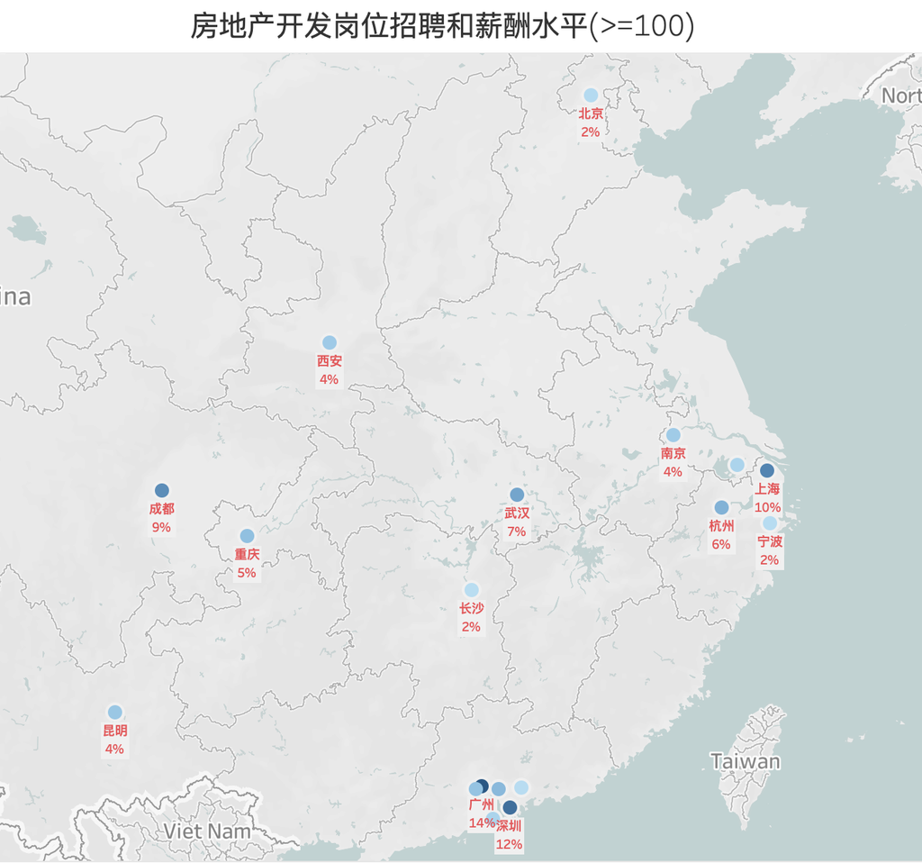

roadmap

## 02.行业分布

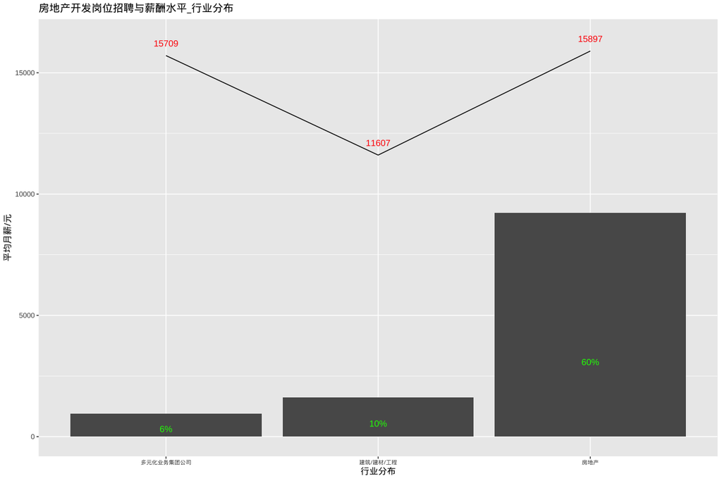

industries

## 03.公司规模

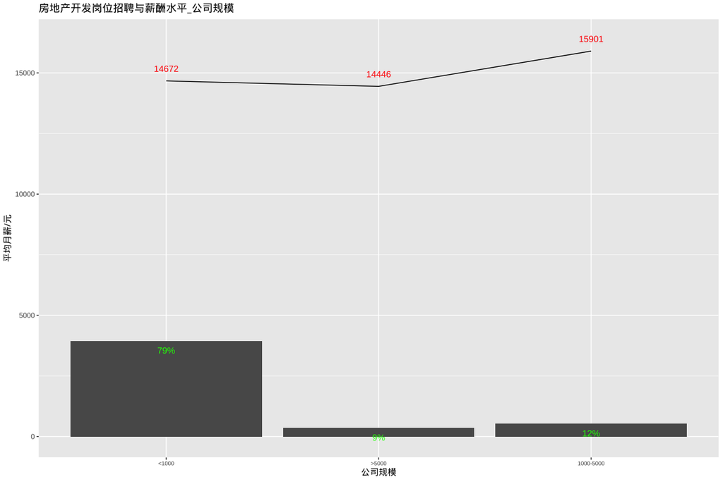

com_size

## 04.公司类型

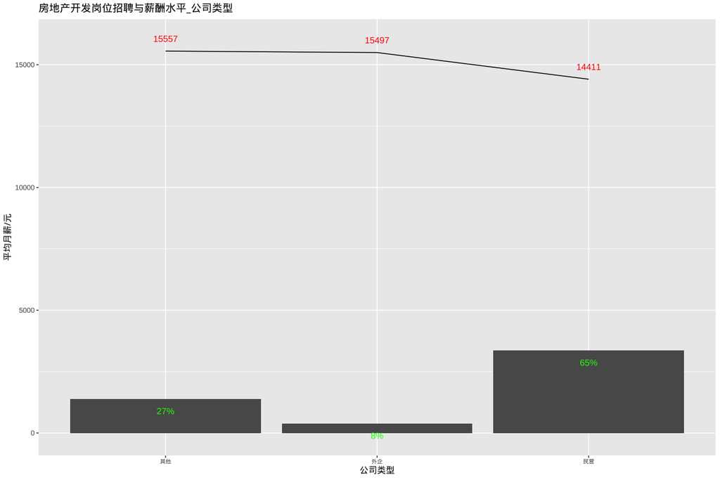

com_type

## 05.工作经验

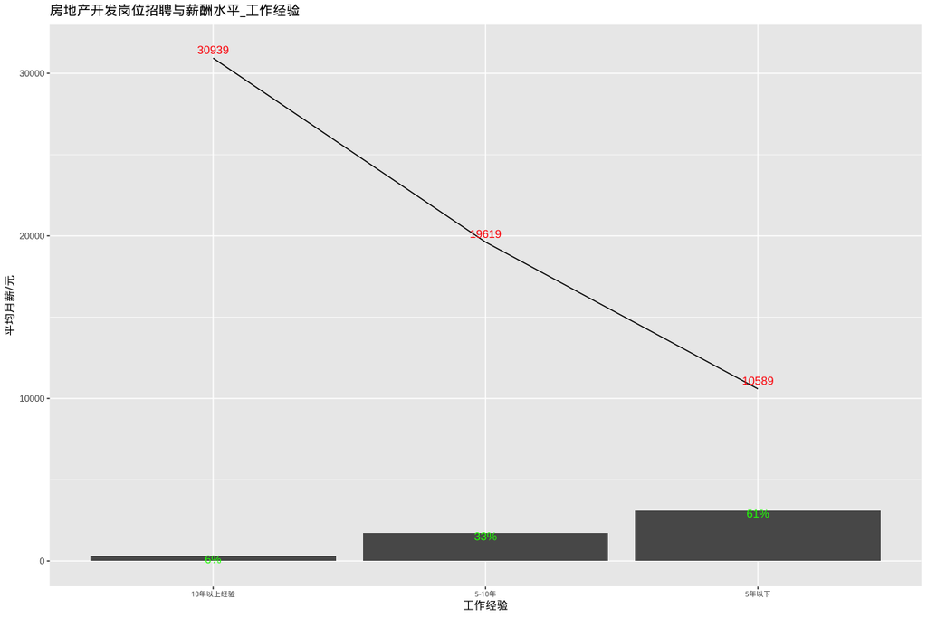

experience

## 06.学历要求

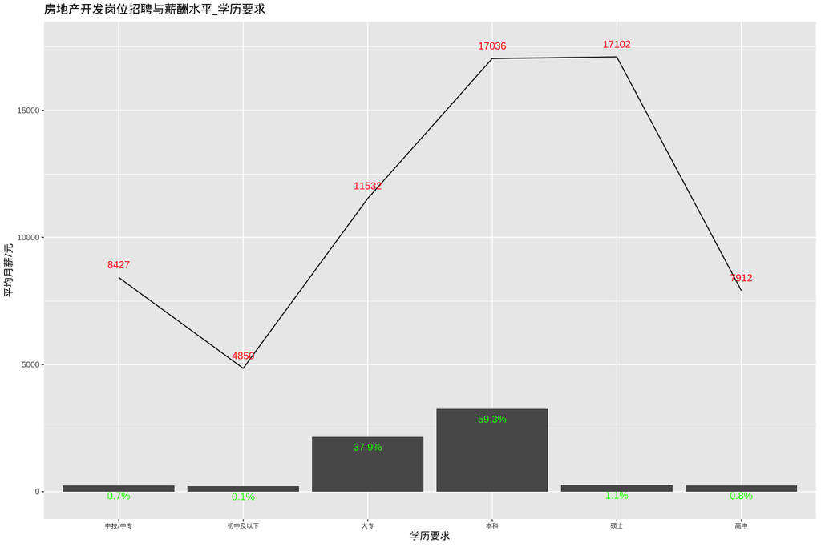

education